# The Impact of Federal Spending on Poverty in the United States

A Snapshot

Alida Norton, Corrina Pascale, and Charlotte Steinhardt

January 13, 2021

Does US federal spending per capita impact a state’s poverty rate? The graph below, derived from 2010 decennial census data, plots federal spending per capita per state (in thousands of dollars)against state poverty rate (the percentage of each state population below the poverty line). [^1] The Census Bureau calculates poverty thresholds based on family size and age of members; these thresholds do not vary by state. [^2]

The line of best fit shown in the plot obviously does not closely fit the data, but seems to indicate a nonlinear general relationship between poverty rate and federal spending: that poverty is lower where federal spending is lowest and highest.

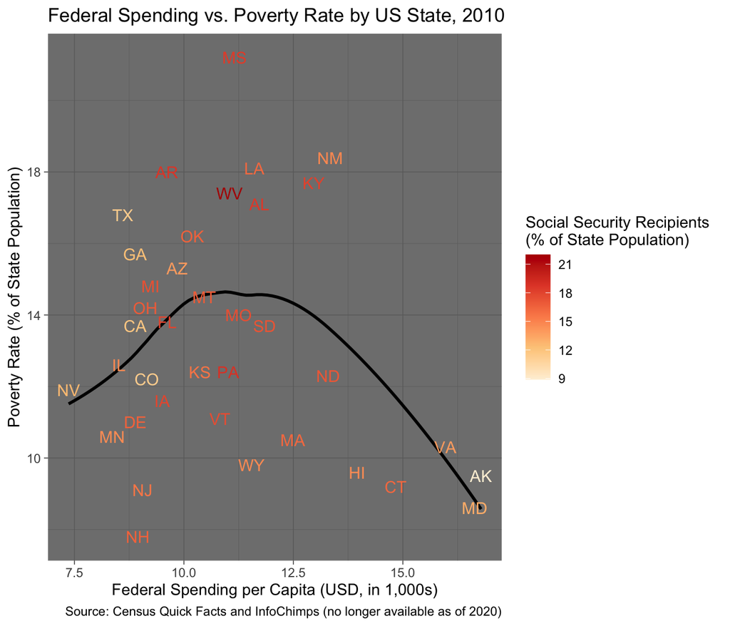

```r
data(state_stats)

state_stats_noDC <- state_stats %>%
  filter(fed_spend < 100)

legend_colors = c("#fef0d9", "#fdcc8a", "#fc8d59", "#e34a33", "#b30000")

our_plot <- ggplot(data = state_stats_noDC, aes(x = fed_spend, y = poverty, color = soc_sec)) +
  geom_smooth(color = "black", fill = "darkslategray", se = FALSE) +
  geom_text(aes(label = abbr), size = 4, check_overlap = TRUE) +
  ggtitle("Federal Spending vs. Poverty Rate by US State, 2010") +
  labs(x = "Federal Spending per Capita (USD, in 1,000s)",
       y = "Poverty Rate (% of State Population)",
       caption = "Source: Census Quick Facts and InfoChimps (no longer available as of 2020)") +
  theme_dark() +
  scale_colour_gradientn(name = "Social Security Recipients \n(% of State Population)", colors = legend_colors)

our_plot
```

What accounts for the variation in federal spending across states? States with the highest per capita federal spending include Maryland and Virginia, who likely have more federal employees and therefore more incoming federal dollars, due to their proximity to Washington, DC.[^3]

Other states with high federal spending allocations, such as Alaska, Hawai’i, and New Mexico, have smaller populations but likely receive more federal funds per person because they host military bases and other government installations. Alaska also requires higher-than-average infrastructure funding and has twenty times the average state population of Indigenous persons, who are eligible for particular federal healthcare programs.[^4] Nevada, which received the lowest funding per capita, seems to have a habitual issue filing effective federal grants.[^5]

The majority of federal funding to states takes the form of entitlement programs; according to Pew estimates from 2014, Social Security and Medicare made up close to 60 percent of total federal spending to states (see table below).[^6]

| Federal Funding Allocation | Percentage of Funds |
| --- | --- |
| Social Security, federal pensions | 34% |
| Medicare | 28% |
| Grants (including Medicaid) | 18% |
| Contracts (mainly defense purchases) | 11% |
| Salaries and wages | 9% |

The graph also shows Social Security recipients as a percentage of state population, where darker saturation corresponds to higher percentages. Social Security acts as an anti-poverty program by providing an income to non-workers; however, the graph does not reveal a discernible pattern between Social Security receipt and the poverty rate, perhaps because the data depicts conditions only within one year, rather than over an extended period of time. States in the mid-range of federal funding appear to have more elevated levels of Social Security recipients.

Overall, although we might have predicted federal spending to be inversely related to state poverty rates, this relationship is not demonstrated in our graph, possibly because of other federal funding sources besides anti-poverty programs like Social Security that account for variation in federal funding per capita across states.

## Word count

| Method | koRpus | stringi |
| --- | --- | --- |
| Word count | 721 | 695 |
| Character count | 4612 | 4972 |
| Sentence count | 57 | Not available |
| Reading time | 3.6 minutes | 3.5 minutes |